# Cyclistic Case Study

Daniel Prashad

2024-04-10

# Google Data Analytics Certification Capstone Project: Cyclistic Case Study

In this case study, I am a data analyst working on the marketing team at a Chicago-based bike-share company called Cyclistic. The director of marketing wants to create a marketing strategy to convert casual riders (those who purchase single-ride or full-day passes) to annual members. My team wants to first understand how casual riders and annual members use Cyclistic bikes differently. Using these insights, the marketing team can then start to devise an effective marketing strategy.

The subsequent analysis follows the six phases outlined in Google’s data analysis process: Ask, Prepare, Process, Analyze, Share and Act.

### **Ask**

The business task presented in this case study is to determine the differences between how casual riders and annual members use Cyclistic bikes. This information will help Cyclistic’s marketing team devise a strategy to convert casual riders into annual members, making the converted users more profitable. The insights gained from the analysis will be provided in this report, as well as a presentation which summarizes the project’s findings with supporting visualizations.

### **Prepare**

The data used in this project was retrieved from Cyclistic’s repository of historical data, which can be found here: https://divvy-tripdata.s3.amazonaws.com/index.html

#### Load the necessary packages for analysis

```r
library(tidyverse)
library(dplyr)
library(lubridate)
library(hms)
library(geosphere)
library (scales)
```

#### Import the data

The data is organized into .csv files by month of use and contains a table where each record holds information pertaining to a specific ride. This information includes: the ride id, type of bike used, start and end times of the ride, start and end station names and ids, start and end latitudes and longitudes, and finally whether the rider was a member or casual rider. The next code chunk reads, stores and combines the previous 12 months of data.

```r
# read in data for last 12 months
rides_2023_03 = read.csv("2023_03_tripdata.csv", sep=",", header=TRUE, na.strings=c("", " ", "NA"))
rides_2023_04 = read.csv("2023_04_tripdata.csv", sep=",", header=TRUE, na.strings=c("", " ", "NA"))
rides_2023_05 = read.csv("2023_05_tripdata.csv", sep=",", header=TRUE, na.strings=c("", " ", "NA"))
rides_2023_06 = read.csv("2023_06_tripdata.csv", sep=",", header=TRUE, na.strings=c("", " ", "NA"))
rides_2023_07 = read.csv("2023_07_tripdata.csv", sep=",", header=TRUE, na.strings=c("", " ", "NA"))
rides_2023_08 = read.csv("2023_08_tripdata.csv", sep=",", header=TRUE, na.strings=c("", " ", "NA"))
rides_2023_09 = read.csv("2023_09_tripdata.csv", sep=",", header=TRUE, na.strings=c("", " ", "NA"))
rides_2023_10 = read.csv("2023_10_tripdata.csv", sep=",", header=TRUE, na.strings=c("", " ", "NA"))
rides_2023_11 = read.csv("2023_11_tripdata.csv", sep=",", header=TRUE, na.strings=c("", " ", "NA"))
rides_2023_12 = read.csv("2023_12_tripdata.csv", sep=",", header=TRUE, na.strings=c("", " ", "NA"))
rides_2024_01 = read.csv("2024_01_tripdata.csv", sep=",", header=TRUE, na.strings=c("", " ", "NA"))
rides_2024_02 = read.csv("2024_02_tripdata.csv", sep=",", header=TRUE, na.strings=c("", " ", "NA"))

# combine the data into one table
combined_raw_data = rbind(rides_2023_03, rides_2023_04, rides_2023_05,
                          rides_2023_06, rides_2023_07, rides_2023_08,
                          rides_2023_09, rides_2023_10, rides_2023_11,
                          rides_2023_12, rides_2024_01, rides_2024_02)
```

#### Initial data exploration

After importing the data, we check that the data set does not contain any duplicate rows.

```r
# check if there are any duplicate rows or ride_ids
cat(sprintf(" Number of duplicate rows: %d\n", sum(duplicated(combined_raw_data))),
    sprintf("Are all ride_ids unique: %s", n_distinct(combined_raw_data$ride_id) == nrow(combined_raw_data)))
```

```
##  Number of duplicate rows: 0
##  Are all ride_ids unique: TRUE
```

Now, taking a quick look at the first 6 rows, we see that there is missing data, specifically the end_station_name and end_station_id columns.

```r
head(combined_raw_data)
```

```
##            ride_id rideable_type          started_at            ended_at
## 1 6842AA605EE9FBB3 electric_bike 2023-03-16 08:20:34 2023-03-16 08:22:52
## 2 F984267A75B99A8C electric_bike 2023-03-04 14:07:06 2023-03-04 14:15:31
## 3 FF7CF57CFE026D02  classic_bike 2023-03-31 12:28:09 2023-03-31 12:38:47
## 4 6B61B916032CB6D6  classic_bike 2023-03-22 14:09:08 2023-03-22 14:24:51
## 5 E55E61A5F1260040 electric_bike 2023-03-09 07:15:00 2023-03-09 07:26:00
## 6 123AAD676850F53C  classic_bike 2023-03-22 17:47:02 2023-03-22 18:01:29
##                     start_station_name start_station_id
## 1              Clark St & Armitage Ave            13146
## 2 Public Rack - Kedzie Ave & Argyle St              491
## 3 Orleans St & Chestnut St (NEXT Apts)              620
## 4            Desplaines St & Kinzie St     TA1306000003
## 5                           Walsh Park            18067
## 6 Orleans St & Chestnut St (NEXT Apts)              620
##               end_station_name end_station_id start_lat start_lng  end_lat
## 1    Larrabee St & Webster Ave          13193  41.91841 -87.63645 41.92182
## 2                         <NA>           <NA>  41.97000 -87.71000 41.95000
## 3       Clark St & Randolph St   TA1305000030  41.89820 -87.63754 41.88458
## 4 Sheffield Ave & Kingsbury St          13154  41.88872 -87.64445 41.91052
## 5        Sangamon St & Lake St   TA1306000015  41.91448 -87.66801 41.88578
## 6  Halsted St & Wrightwood Ave   TA1309000061  41.89820 -87.63754 41.92914
##     end_lng member_casual
## 1 -87.64414        member
## 2 -87.71000        member
## 3 -87.63189        member
## 4 -87.65311        member
## 5 -87.65102        member
## 6 -87.64908        member
```

Now that we know that our data set contains incomplete data, lets dive deeper and find out which columns have missing values. From the code chunk below, we see that quite a lot of geographical data that is missing, specifically the start and end station names and ids, as well as end latitudes and longitudes. The missing data makes up almost 5% of the data set.

```r
# display the number of missing values for each row
colSums(is.na(combined_raw_data))
```

```
##            ride_id      rideable_type         started_at           ended_at
##                  0                  0                  0                  0
## start_station_name   start_station_id   end_station_name     end_station_id
##             866105             866105             920524             920524
##          start_lat          start_lng            end_lat            end_lng
##                  0                  0               7353               7353
##      member_casual
##                  0
```

```r
# show the amount and percentage of missing data
num_missing_values = sum(colSums(is.na(combined_raw_data)))
num_possible_values = nrow(combined_raw_data) * length(colnames(combined_raw_data))
cat(sprintf(" Number of missing values: %d\n", num_missing_values),
    sprintf("Number of possible values: %d\n", num_possible_values),
    sprintf("Percentage of missing data: %0.2f%%", 100*num_missing_values/num_possible_values))
```

```
##  Number of missing values: 3587964
##  Number of possible values: 74193184
##  Percentage of missing data: 4.84%
```

Next, we will ensure that any data that should not be a string type is of the correct type. Note that while the start and end latitudes and longitudes are correct, started_at and ended_at should both be date-time type. This error will be corrected in the Process phase.

```r
# check the datatype of each column that should not be a string
cat(sprintf(" Type of started_at: %s\n", typeof(combined_raw_data$started_at)),
    sprintf("Type of ended_at: %s\n",typeof(combined_raw_data$ended_at)),
    sprintf("Type of start_lat: %s\n",typeof(combined_raw_data$start_lat)),
    sprintf("Type of start_lng: %s\n",typeof(combined_raw_data$start_lng)),
    sprintf("Type of end_lat: %s\n",typeof(combined_raw_data$end_lat)),
    sprintf("Type of end_lng: %s",typeof(combined_raw_data$end_lng)))
```

```
##  Type of started_at: character
##  Type of ended_at: character
##  Type of start_lat: double
##  Type of start_lng: double
##  Type of end_lat: double
##  Type of end_lng: double
```

Finally, we will check for rides that have a start time that is greater than or equal to its end time. We see that there are 1377 occurrences of this. In these cases, the ride was likely either cancelled or another error occurred while tracking the ride. Again, this will be corrected in the process phase.

```r
# display number of rows where start time is greater than or equal to end time
combined_raw_data %>%
  filter(started_at >= ended_at) %>%
  nrow
```

```
## [1] 1377
```

#### Summary of the Prepare Phase

In this phase, we retrieved the latest 12 months of historical data from Cyclistic’s data repository. After taking a quick look at the data set, we identified that it contains missing data; so we can say that the data is not comprehensive, as about 5% of the entire data set contains missing values. For this reason, as well as the incorrect typing of columns and the existence of inaccurate start and end times, we can also say that the data set is not exactly reliable. However, since the latest 12 months of data was retrieved from Cyclistic’s repository, we can say that it is current, original and cited.

### **Process**

The goal of this phase is to clean the data to correct the mistakes found in the prepare phase and manipulate the data in ways that will make it more useful to us in the analyze phase. Specifically, we want to address the comprehensive and reliability issues mentioned above.

The first change that will be made to the data is to split it into two subsets; one with the records containing complete data and the other containing records with missing data.

```r
# split the data set into two
completed_data = combined_raw_data[rowSums(is.na(combined_raw_data)) == 0,]
rows_with_missing_data = combined_raw_data[rowSums(is.na(combined_raw_data)) > 0,]

# calculate and show the number and percentage of rows with missing data
cat(sprintf(" Number of rows with missing values: %d\n", nrow(rows_with_missing_data)),
    sprintf("Percentage of rows with missing values, %0.2f%%", 100*nrow(rows_with_missing_data)/nrow(combined_raw_data)))
```

```
##  Number of rows with missing values: 1374761
##  Percentage of rows with missing values, 24.09%
```

Now that we have a subset of data that is complete, we will work on correcting the mistakes so that the data is more reliable. The first correction that will be made is to change the datatype of the start and end times to date-time.

```r
# convert the start and end times to a date-time format
completed_data$started_at = ymd_hms(completed_data$started_at)
completed_data$ended_at = ymd_hms(completed_data$ended_at)
```

Next, as mentioned in the prepare phase, we will filter out rides that have a start time that is greater than or equal to its end time.

```r
completed_data = completed_data %>%
                  filter(started_at < ended_at)
```

Our next step is the creation of a new column (called ride_length), which uses the start and end times to calculate and store the total duration of the ride.

```r
completed_data = mutate(completed_data, ride_length = as_hms(difftime(completed_data$ended_at, completed_data$started_at)))
```

Using ride_length, we will filter out other extreme outliers; those being rides that lasted less than one minute or longer than eight hours. These rides are not representative of a normal riding experience.

```r
completed_data = completed_data %>%
  filter(ride_length >= 60) %>%
  filter(ride_length < 28800)
```

The last manipulation to be made is the creation of four more columns: day_of_week, month, start_hour and distance. The first three store the day of week, month and hour of which the ride started, respectively. Lastly, distance calculates and stores the distance (in meters) between the start station and end station. These newly created columns, along with ride_length, will be used in the analyze phase coming up next.

```r
completed_data = completed_data %>%
                  mutate(day_of_week=weekdays(completed_data$started_at)) %>%
                  mutate(month = month.abb[as.numeric(format(completed_data$started_at, "%m"))]) %>%
                  mutate(start_hour = hour(completed_data$started_at)) %>%
                  mutate(distance = distHaversine(cbind(start_lng, start_lat), cbind(end_lng, end_lat)))
```

Finally, we will take a look at the first few rows of our manipulated data set to ensure that it is clean and reliable.

```r
head(completed_data)
```

```
##            ride_id rideable_type          started_at            ended_at
## 1 6842AA605EE9FBB3 electric_bike 2023-03-16 08:20:34 2023-03-16 08:22:52
## 2 FF7CF57CFE026D02  classic_bike 2023-03-31 12:28:09 2023-03-31 12:38:47
## 3 6B61B916032CB6D6  classic_bike 2023-03-22 14:09:08 2023-03-22 14:24:51
## 4 E55E61A5F1260040 electric_bike 2023-03-09 07:15:00 2023-03-09 07:26:00
## 5 123AAD676850F53C  classic_bike 2023-03-22 17:47:02 2023-03-22 18:01:29
## 6 5929D3080983AF4F  classic_bike 2023-03-08 19:58:44 2023-03-08 20:05:39
##                     start_station_name start_station_id
## 1              Clark St & Armitage Ave            13146
## 2 Orleans St & Chestnut St (NEXT Apts)              620
## 3            Desplaines St & Kinzie St     TA1306000003
## 4                           Walsh Park            18067
## 5 Orleans St & Chestnut St (NEXT Apts)              620
## 6                 Rush St & Hubbard St     KA1503000044
##               end_station_name end_station_id start_lat start_lng  end_lat
## 1    Larrabee St & Webster Ave          13193  41.91841 -87.63645 41.92182
## 2       Clark St & Randolph St   TA1305000030  41.89820 -87.63754 41.88458
## 3 Sheffield Ave & Kingsbury St          13154  41.88872 -87.64445 41.91052
## 4        Sangamon St & Lake St   TA1306000015  41.91448 -87.66801 41.88578
## 5  Halsted St & Wrightwood Ave   TA1309000061  41.89820 -87.63754 41.92914
## 6          Wells St & Huron St   TA1306000012  41.89017 -87.62619 41.89472
##     end_lng member_casual ride_length day_of_week month start_hour  distance
## 1 -87.64414        member    00:02:18    Thursday   Mar          8  741.3489
## 2 -87.63189        member    00:10:38      Friday   Mar         12 1587.4419
## 3 -87.65311        member    00:15:43   Wednesday   Mar         14 2531.2161
## 4 -87.65102        member    00:11:00    Thursday   Mar          7 3491.2648
## 5 -87.64908        member    00:14:27   Wednesday   Mar         17 3574.4510
## 6 -87.63436        member    00:06:55   Wednesday   Mar         19  845.9141
```

#### Summary of the Process Phase

In this phase, we ensured the integrity of the data by addressing the comprehensive and reliability issues mentioned in the prepare phase. Now focusing on the complete data, we corrected the data type of the started_at and ended_at columns. We also filtered out rides that had a duration of less than one minute or more than eight hours, as those rides are neither typical or representative of a normal riding experience with Cyclistic. Finally, we created the additional columns ride_length, day_of_week, month, start_hour and distance which will all be used extensively to help us in our analysis in the next phase. With this revised data set, we are now better equipped to solve the original business task, which is to determine the differences between how casual riders and annual members use Cyclistic bikes.

### **Analyze**

The goal of the analyze phase is to use the data to reach insights and uncover answers and solutions to our original business task: to determine the differences between how casual riders and annual members use Cyclistic bikes. My initial hypothesis is that casual riders use Cyclistic bikes for leisure, while annual members are more likely to use them to commute to and from work. We will do this by comparing the two groups in terms of frequency of rides over various periods of time, time spent riding and distance ridden.

Starting with frequency of rides, we will work our way from visualizing the number of rides by season, then by month, then by day of the week and finally by hour. Let’s start by comparing the groups by season. Taking a look at the graphs and data table below, we can see that less casual riders use Cyclistic bikes during the Winter and Spring than annual members, but tend to use them more in the Summer. Also note that the difference between the number of rides in each group in the Fall is not significant. The correlation that could be made here is that casual riders tend to prefer to use Cyclistic bikes in better weather, since it tends to snow and rain more in the Winter and Spring respectively. This reinforces the claim that casual riders generally use the bikes for leisure.

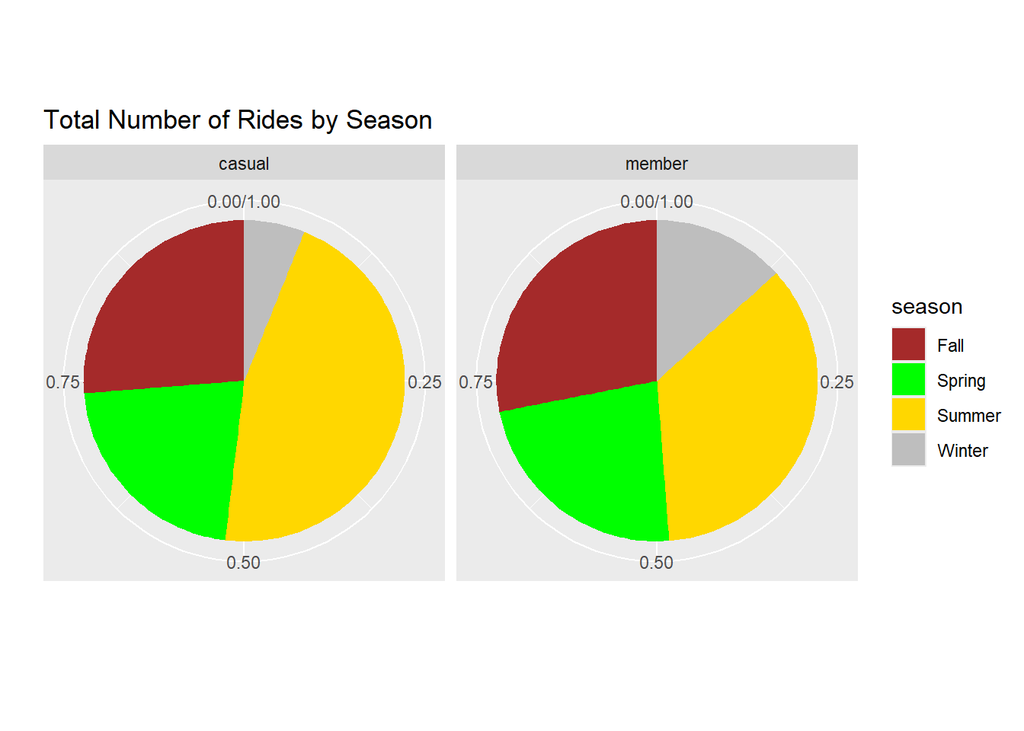

```r
# create a data frame to store the number of rides by month, grouped by membership status
monthly_dist = completed_data %>%
                group_by(member_casual) %>%
                count(month) %>%
                rename(num_rides = n) %>%
                mutate(pct = round(num_rides/sum(num_rides)*100, 2))

# add a column to store the season in which each ride took place
monthly_dist = mutate(monthly_dist, season = case_when(
                month %in% c("Mar", "Apr", "May") ~ "Spring",
                month %in% c("Jun", "Jul", "Aug") ~ "Summer",
                month %in% c("Sep", "Oct", "Nov") ~ "Fall",
                month %in% c("Dec", "Jan", "Feb") ~ "Winter"
                )
               )
# create a data frame to store the data about the number of rides by members
# per season
seasonal_data = monthly_dist %>%
                group_by(member_casual, season) %>%
                summarize(sum(num_rides)) %>%
                rename(num_rides = `sum(num_rides)`) %>%
                mutate(pct = round(num_rides/sum(num_rides)*100, 2))

# plot two pie graphs that show the number of rides by season per group
ggplot(seasonal_data, aes(x=1, y=num_rides, fill=season)) +
  geom_col(position="fill") +
  scale_fill_manual(values = c("brown", "green", "gold", "grey")) +
  coord_polar(theta="y") +
  facet_wrap(~member_casual) +
  ggtitle("Total Number of Rides by Season") +
  theme(axis.text.y = element_blank(), axis.ticks.y = element_blank()) +
  labs(x = "", y = "")
```

```r
# display the data frame to show the percentage of rides per season by group
data.frame(seasonal_data) %>%
  arrange(season)
```

```
##   member_casual season num_rides   pct
## 1        casual   Fall    392662 26.25
## 2        member   Fall    771650 28.10
## 3        casual Spring    326960 21.85
## 4        member Spring    634632 23.11
## 5        casual Summer    685554 45.82
## 6        member Summer    974697 35.49
## 7        casual Winter     90943  6.08
## 8        member Winter    365561 13.31
```

Next, comparing the number of rides per month by group, we see that a higher percentage of all casual riders than annual members use Cyclistic bikes from May to September. The percentage of rides from all annual members between October to April is higher than that of casual riders. Again, this supports the correlation between weather and the number of casual riders using Cyclistic bikes. Although poor weather may be more of a deterrent to casual riders, annual members may be more willing to cycle in such conditions because they have already paid for their membership.

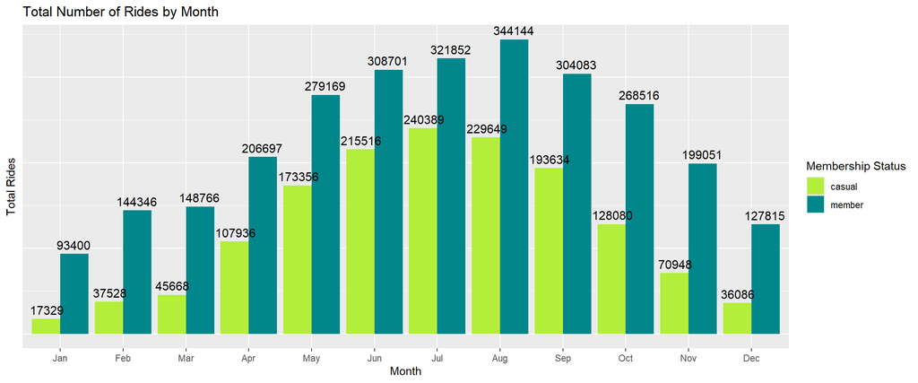

```r
# create a vector to store the months of the year in chronological order
chron_months = c("Jan", "Feb", "Mar", "Apr", "May", "Jun",
                 "Jul", "Aug", "Sep", "Oct", "Nov", "Dec")

# display a double bar graph to compare the number of rides per month by group
ggplot(monthly_dist, aes(x=factor(month, levels=chron_months), y=num_rides, fill=member_casual, label=num_rides)) +
  geom_bar(stat="identity", position="dodge") +
  scale_fill_manual(name = "Membership Status", values = c("olivedrab2", "turquoise4")) +
  labs(title = "Total Number of Rides by Month", x="Month", y="Total Rides") +
  geom_text(size=4, position = position_dodge(width = 0.85), vjust=-0.5) +
  theme(axis.text.y = element_blank(), axis.ticks.y = element_blank())
```

```r
# display the accompanying data frame to include the percentages of rides per month
data.frame(monthly_dist) %>%
  select(member_casual, month, pct) %>%
  arrange(levels=c(chron_months, chron_months))
```

```
##    member_casual month   pct
## 1         casual   Feb  2.51
## 2         member   Feb  5.26
## 3         casual   Mar  3.05
## 4         member   Mar  5.42
## 5         casual   Sep 12.94
## 6         member   Sep 11.07
## 7         casual   Aug 15.35
## 8         member   Aug 12.53
## 9         casual   Apr  7.21
## 10        member   Apr  7.53
## 11        casual   Jun 14.41
## 12        member   Jun 11.24
## 13        casual   Jul 16.07
## 14        member   Jul 11.72
## 15        casual   Dec  2.41
## 16        member   Dec  4.65
## 17        casual   Jan  1.16
## 18        member   Jan  3.40
## 19        casual   Oct  8.56
## 20        member   Oct  9.78
## 21        casual   Nov  4.74
## 22        member   Nov  7.25
## 23        casual   May 11.59
## 24        member   May 10.16
```

Now, comparing the number of rides by day of the week for each group, we see that the highest frequency of rides in the casual riders group occurs on the weekend, while the highest frequency for annual members occurs during the week. This supports the claim that the average casual rider uses Cyclistic bikes for leisure, while annual members are more likely to use the bikes to commute to work.

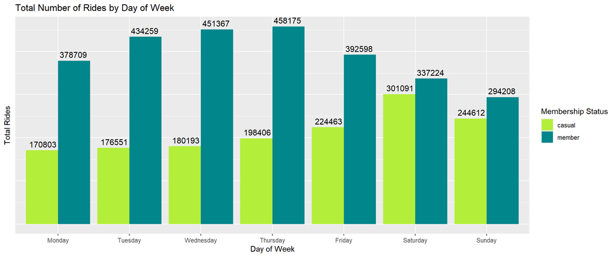

```r
# add a column to store whether each day of the week is a regular weekday or during the weekend
weekdays = c("Monday", "Tuesday", "Wednesday", "Thursday", "Friday")
weekends = c("Saturday", "Sunday")

# create a data frame to store the number of rides by day of week, grouped by membership status
daily_dist = completed_data %>%
                group_by(member_casual) %>%
                count(day_of_week) %>%
                rename(num_rides = n) %>%
                mutate(pct = round(num_rides/sum(num_rides)*100, 2)) %>%
                mutate(weekday_weekend = ifelse(day_of_week %in% weekdays, "weekday", "weekend"))

# display a double bar graph to compare the number of rides by the day of the week for each group
ggplot(daily_dist, aes(x=factor(day_of_week, levels=c(weekdays,weekends)), y=num_rides, fill=member_casual, label=num_rides)) +
  geom_bar(stat="identity", position="dodge") +
  scale_fill_manual(name = "Membership Status",values = c("olivedrab2", "turquoise4")) +
  labs(title = "Total Number of Rides by Day of Week", x="Day of Week",
       y="Total Rides") +
  geom_text(size=4, position = position_dodge(width = 0.85), vjust=-0.5)  +
  theme(axis.text.y = element_blank(), axis.ticks.y = element_blank())
```

```r
# display the accompanying data frame to include the percentages of rides per day
data.frame(daily_dist) %>%
  select(member_casual, day_of_week, pct) %>%
  arrange(day_of_week)
```

```
##    member_casual day_of_week   pct
## 1         casual      Friday 15.00
## 2         member      Friday 14.29
## 3         casual      Monday 11.42
## 4         member      Monday 13.79
## 5         casual    Saturday 20.12
## 6         member    Saturday 12.28
## 7         casual      Sunday 16.35
## 8         member      Sunday 10.71
## 9         casual    Thursday 13.26
## 10        member    Thursday 16.68
## 11        casual     Tuesday 11.80
## 12        member     Tuesday 15.81
## 13        casual   Wednesday 12.04
## 14        member   Wednesday 16.43
```

Continuing from the last graph, we will now compare the number of rides by starting hour for each group. Taking a look at the first graph, which compares the number of rides between groups by starting hour during weekdays, we see that there is an influx in rides started from 4:00pm to 6:00pm (which is generally the end of a typical work day) for both members and casual riders. However, there is another peak for members, which is from 7:00am to 8:00am. This could be because many members use Cyclistic bikes to commute to work, while casual riders do not. Casual riders are likely riding for leisure during the peak from 4:00pm to 6:00pm, while members who commuted to work using Cyclistic bikes are more likely using them to commute back home after work. Now, looking at the same metrics in the second graph, but this time only considering weekends, we see that both groups have an almost identical trend. Since the trends are so similar on the weekends, when all riders typically do not have to commute to work; it is again reinforced that many annual members use Cyclistic bikes to commute to work, while most casual riders instead use the bikes for leisure.

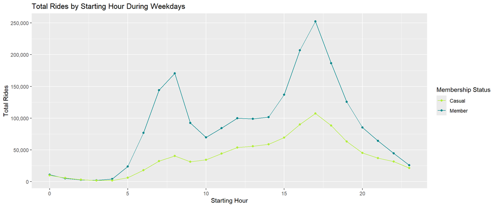

```r
# create a data frame to store the number of rides by starting hour during the week, grouped by membership status
hourly_dist_weekdays = completed_data %>%
                        filter(day_of_week %in% weekdays) %>%
                        group_by(member_casual) %>%
                        count(start_hour) %>%
                        rename(num_rides=`n`)

# make subsets of the data, one for members and another for casual riders so that they can be plotted separately
weekday_members_by_hour = filter(hourly_dist_weekdays, member_casual=="member")
weekday_casuals_by_hour = filter(hourly_dist_weekdays, member_casual=="casual")

# display a double line graph to compare the number of rides by starting hour for weekdays between groups
ggplot() +
  geom_line(data=weekday_members_by_hour, mapping=aes(x=start_hour, y=num_rides, color="turquoise4")) +
  geom_point(data=weekday_members_by_hour, mapping=aes(x=start_hour, y=num_rides, color="turquoise4")) +
  geom_line(data=weekday_casuals_by_hour, mapping=aes(x=start_hour, y=num_rides, color="olivedrab2")) +
  geom_point(data=weekday_casuals_by_hour, mapping=aes(x=start_hour, y=num_rides, color="olivedrab2")) +
  labs(title = "Total Rides by Starting Hour During Weekdays", x="Starting Hour", y="Total Rides", color = "Membership Status") +
  scale_color_identity(guide="legend", labels=c("Casual", "Member")) +
  scale_y_continuous(labels = label_comma())
```

[figure not shown]

```r
# create a data frame to store the number of rides by starting hour during the weekend, grouped by membership status
hourly_dist_weekends = completed_data %>%
                        filter(day_of_week %in% weekends) %>%
                        group_by(member_casual) %>%
                        count(start_hour) %>%
                        rename(num_rides=`n`)

# make subsets of the data, one for members and another for casual riders so that they can be plotted separately
weekend_members_by_hour = filter(hourly_dist_weekends, member_casual=="member")
weekend_casuals_by_hour = filter(hourly_dist_weekends, member_casual=="casual")

# display a double line graph to compare the number of rides by starting hour for weekends between groups
ggplot() +
  geom_line(data=weekend_members_by_hour, mapping=aes(x=start_hour, y=num_rides, color="turquoise4")) +
  geom_point(data=weekend_members_by_hour, mapping=aes(x=start_hour, y=num_rides, color="turquoise4")) +
  geom_line(data=weekend_casuals_by_hour, mapping=aes(x=start_hour, y=num_rides, color="olivedrab2")) +
  geom_point(data=weekend_casuals_by_hour, mapping=aes(x=start_hour, y=num_rides, color="olivedrab2")) +
  labs(title = "Total Rides by Starting Hour During Weekdays", x="Starting Hour", y="Total Rides", color = "Membership Status") +
  scale_color_identity(guide="legend", labels=c("Casual", "Member")) +
  scale_y_continuous(labels = label_comma())
```

Now, we will compare the average ride duration between groups by the day of the week. From the graph below, we can see that on average casual riders spend a significantly longer time, almost twice as long, per ride than annual members. This is the case throughout the entirety of the week; during the work week when there are many more annual members using the bikes and during weekends when that is not the case. This is another indication that casual riders use Cyclistic bikes for leisure, as the data supports that they are likely not in a rush and using the bike as a form of faster transportation than walking. Also note that there is more variance in the average duration in the casual riders group than in the annual members group. The average duration in the annual members group is quite stable during the work week, again providing supporting evidence that they use Cyclistic bikes to commute to and from work, which is quite possible in about 11 or 12 minutes.

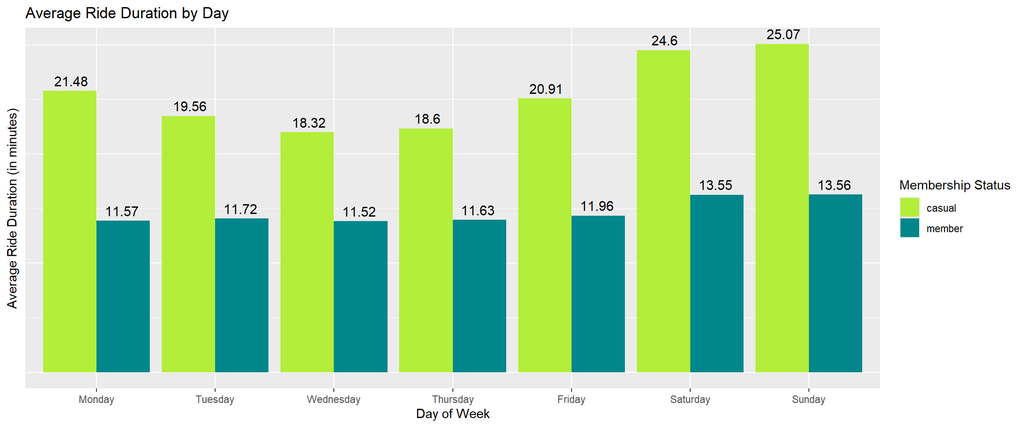

```r
# create a data frame to store the average length ridden by day of the week, grouped by membership status
daily_avg_length = completed_data %>%
                    group_by(member_casual,day_of_week) %>%
                    summarize(mean(ride_length)) %>%
                    rename(average_ride_length = `mean(ride_length)`)

# display a double bar graph to compare the average ride duration by the day of the week for each group
ggplot(daily_avg_length, aes(x=factor(day_of_week, levels=c(weekdays,weekends)), y=average_ride_length, fill=member_casual, label=round(average_ride_length/60,2))) +
  geom_bar(stat="identity", position="dodge") +
  scale_fill_manual(name = "Membership Status", values = c("olivedrab2", "turquoise4")) +
  labs(title = "Average Ride Duration by Day", x="Day of Week", y="Average Ride Duration (in minutes)") +
  geom_text(size=4, position = position_dodge(width = 0.85), vjust=-0.5) +
  theme(axis.text.y = element_blank(), axis.ticks.y = element_blank())
```

Finally, we will take a look at the differences in average distance between the start and end stations for each group. It is important to note that this is not the total distance ridden, but the distance between the station where the rider picked up their bike to start a trip and the station where they dropped it off to end a trip. Looking at the graph below, the distance between start and end stations for casual riders is slightly more than annual members; however this does not seem like a significant difference. Also, considering that the average duration spent riding by casual riders is generally almost double that of annual members, the lack of a significant difference in the average distance implies that casual riders could be riding at a slower and more leisurely pace. Alternatively, it may be the case that casual riders are less likely to take a direct route if they are riding for leisure. Consequently, the additional time that they ride would not be reflected in the distance between their start and end stations. The last scenario to explain this is that the average distance could have been reduced by multiple calculated distances of 0, which would be the case when a trip is started and ended at the same station. Looking at the second output, which is a data frame that contains the total number and percentage of rides that start and end at the same station, we see that casual riders tend to fit in this scenario more frequently. Again, this is more supporting evidence that casual riders use Cyclistic bikes for leisure, while annual members are more likely to use the bike to commute to and from work.

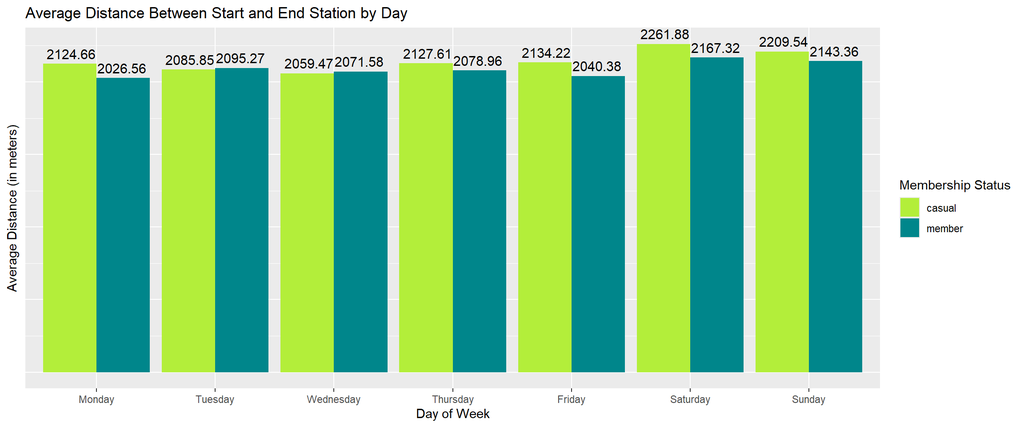

```r
daily_avg_distance = completed_data %>%
                      select(member_casual, day_of_week, distance) %>%
                      group_by(member_casual, day_of_week) %>%
                      summarize(mean(distance)) %>%
                      rename(average_distance = `mean(distance)`)

# display a double bar graph to compare the average difference in distance between start and end station by the day of the week for each group
ggplot(daily_avg_distance, aes(x=factor(day_of_week, levels=c(weekdays,weekends)), y=average_distance, fill=member_casual, label=round(average_distance,2))) +
  geom_bar(stat="identity", position="dodge") +
  scale_fill_manual(name = "Membership Status", values = c("olivedrab2", "turquoise4")) +
  labs(title = "Average Distance Between Start and End Station by Day", x="Day of Week", y="Average Distance (in meters)") +
  geom_text(size=4, position = position_dodge(width = 0.85), vjust=-0.5) +
  theme(axis.text.y = element_blank(), axis.ticks.y = element_blank())
```

```r
# create variables to store the total number of rides by members and casual riders respectively
num_members = nrow(filter(completed_data, member_casual == "member"))
num_casuals = nrow(filter(completed_data, member_casual == "casual"))

# create variables to store the total number of rides by members and casual riders respectively where the bike was picked up and dropped off at the same station
num_members_zero_distance = completed_data %>%
                            filter(member_casual == "member") %>%
                            filter(distance == 0) %>%
                            nrow()
num_casuals_zero_distance = completed_data %>%
                            filter(member_casual == "casual") %>%
                            filter(distance == 0) %>%
                            nrow()

# create and output a data frame that contains the calculated totals and percentages for each group
membership_status = c("member", "casual")
num_zero_distance_rides = c(num_members_zero_distance, num_casuals_zero_distance)
percentage = c(round(100 * num_members_zero_distance / num_members, 2), round(100 * num_casuals_zero_distance / num_casuals, 2))
data.frame(membership_status, num_zero_distance_rides, percentage)
```

```
##   membership_status num_zero_distance_rides percentage
## 1            member                   49230       1.79
## 2            casual                   89025       5.95
```

#### Summary of the Analyze Phase

In this phase, we analyzed and visualized the data to reach insights about the differences in how casual riders and annual members use Cyclistic bikes. Firstly, we found that casual riders are less likely to use Cyclistic bikes in the Winter and Spring (specifically between October and April) than annual members, presumably due to harsher weather conditions. Secondly, the highest frequency of rides by casual riders occurs on the weekends, while that of annual members occurs during the week. Thirdly, although the number of rides by starting hour are similar between groups on the weekends; during the week, annual members tend to have an influx of rides started between 7:00am and 8:00am, which are common commuting hours. This suggests that annual members are more likely to be using Cyclistic bikes to commute to and from work than casual riders. Furthermore, on average casual riders spend a significantly longer time, almost twice as long, per ride than annual members. Also note that there is more variance in the average duration in the casual riders group than in the annual members group. The average duration in the annual members group is quite stable during the work week. Finally, the average distance between the start and end station for each group are very similar. Given that casual riders, on average, spend almost twice as long riding, I presume that this is a result of one of the following three cases. Either casual riders cover a similar overall distance to annual members but ride at a slower and more leisurely pace, or they spend more time and cover more distance but do not take a direct route from their start station to end station, or they more often start and end at the same station. All three of these cases describe a scenario in which a casual rider would use a Cyclistic bike for leisure.

### **Share**

The full slide deck for the presentation can be found here: https://github.com/Daniel-Prashad/CyclisticCaseStudy

Below is a summary of the findings.

The data supports the idea that casual riders use Cyclistic bikes for leisure, while annual members are more likely to use them to commute to and from work.

The three main factors leading to this conclusion are:

1. **Casual riders prefer better weather conditions more than annual members**
- Casual riders more strongly opt to ride during the *Summer*
- Casual riders are more likely to use Cyclistic bikes from *May to September* than members
  - This is likely because the *temperature* and *lack of precipitation* are more suitable for a leisurely ride
2. **Casual riders ride more frequently on the weekends, while annual members ride more frequently during the week**
- Both groups have *similar trends* in the number of rides by hour on the *weekends*
- Both groups have an influx of rides started from 4:00pm to 6:00pm during the week
- Annual members have an additional peak during the week, from *7:00am to 8:00am* (common commuting hours)
3. **On average, casual riders spend almost twice as long per ride than members, but do not end their ride much further**
- This could be because casual riders are more likely to:
  1. Ride at a slower and more *leisurely pace*
  2. *Not take a direct route* between their start and end stations
  3. Start and end at the *same station*

### **Act**

Before an effective marketing strategy aimed to convert casual riders to annual members can be developed, I would suggest that the next step be to *collect additional data to reaffirm the conclusions drawn above*.

Specifically, my suggestions are to:

1. **Employ a randomly generated Rider ID for each user**
- This will help better track the riding habits of a single user
2. **Collect the *temperature* and *precipitation* (dry/rain/snow) for the start of each trip**
- This will help better describe the relationship between each group and weather
3. **Collect the *total distance* ridden during each ride**
- This will help better understand the relationship between ride duration and distance

Once this data is collected, a similar analysis can be redone in order to increase the confidence of the conclusions drawn in this analysis. This will help better understand the differences between how casual riders and annual members use Cyclistic bikes. At that point, the marketing team would be better equipped to devise an effective marketing strategy aimed to convert casual riders to annual members.